# Leitura do tempo de resposta para 100 caracteres e poucos usuários, para os 2 níveis(add e del).

Grupo: Jobson Lucas Dias, José Benardi Nunes, Rafael Albuquerque

# Arquivos aqui avaliados

Neste arquivo, iremos comparar os dados das medições Log1TIME e Log2TIME, que dizem respeito ao tempo de resposta, 100 caracteres em um arquivo e poucos usuários.

# A estratégia utilizada:

Como a api Java utilizada usa como base para o cálculo dos milissegundos a meia noite de janeiro de 1970 UTC, e portanto, o tempo em milissegundos dará um valor muito grande, não é tão útil colocarmos no gráfico os valores deles em si; é mais adequado, no entanto, colocarmos o valor da diferença, que também está medida em milissegundos.

# Gráfico para operação de add com poucos usuários e um arquivo de 100 caracteres.

[interactive chart not shown]

# Gráfico para operação de deletar com poucos usuários e um arquivo de 100 caracteres.

[interactive chart not shown]

# Análise para operação de add:

Notamos que, no gráfico de add, existem indícios de alguns outliers, como na leitura 41 (cujo valor é 1131 milissegundos), pois ela se distanciou muito das demais em termos de diferença em milissegundos. Vamos fazer uma visualização de um box-plot para essa medição de modo a constarmos se, de fato, existem outliers.

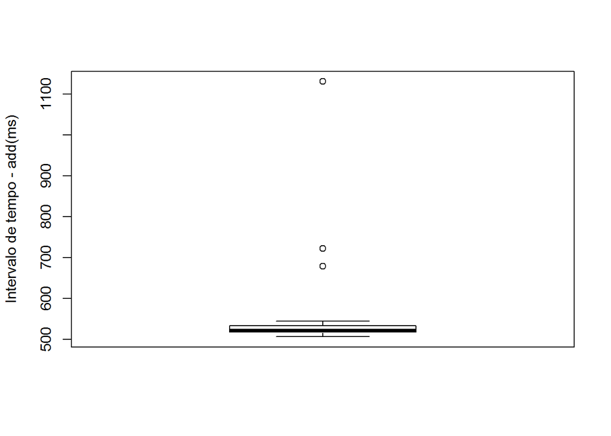

## Conclusão

Nossa asserção sobre a existência de outliers estava correta e foi confirmada pelo boxplot acima. Existem, ao todo, 3 outliers. Como a média, a variância e o desvio padrão não são medidas robustas, elas tenderão a sofrer muito o impacto desses valores. Dessa forma, a mediana talvez fosse uma medida estatística mais apropriada, já que ela não sofre com a presença deles.

# Análise para operação de deletar(del):

Notamos que, no gráfico referente à operação deletar, existem indícios de alguns outliers, como na leitura 39, pois ela se distanciou de maneira singular com relação às demais em termos de diferença em milissegundos. Vamos fazer uma visualização de um box-plot para essa medição de modo a constarmos se, de fato, existe algum outlier.

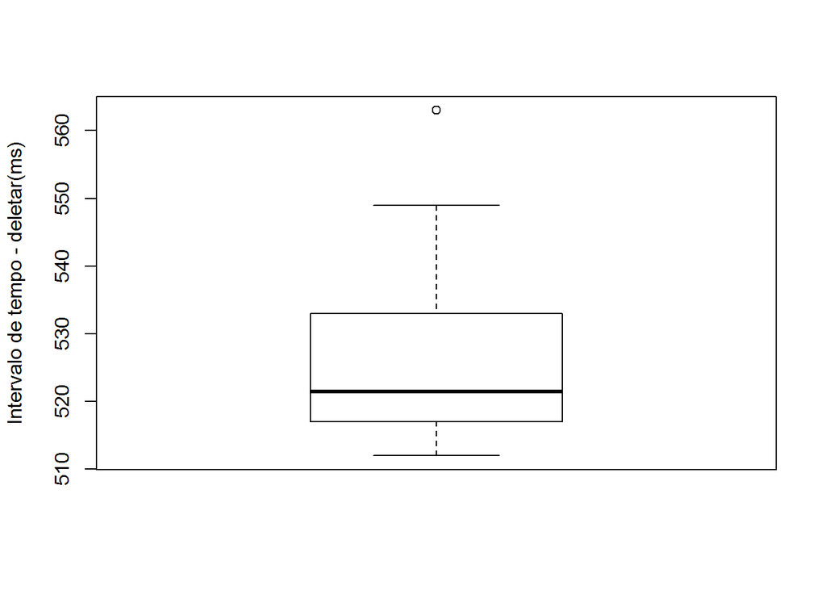

## Conclusão

De fato, nossa hipótese sobre a presença de outlier estava correta e foi confirmada pelo boxplot acima. Como a média, a variância e o desvio padrão não são medidas robustas, elas tenderão a sofrer com impacto desse outlier. Dessa forma, a mediana talvez fosse uma medida estatística mais apropriada, já que ela não sofre com a presença deles.

# Medidas estatísticas para operação de add

Abaixo veremos a média, mediana, e desvio padrão, além do intervalo de confiança(i.c.) com 95% de confiança para os dados dessa operação. Também vamos avaliar o grau de representatividade da média através do coeficiente de variação(cv), que também server para nos indicar a homogeneidade (se os valores estão ao redor da média), a precisão dos dados e a variabilidade com relação à média (quanto o conjunto se afasta da média). Como resultado direto, temos que quanto menor o c.v., maior a homogeneidade e a precisão do conjunto de dados. Além disso, se o valor do cv for menor que 50%, então a média é dita representativa; não, caso contrário.

```
## [1] "o valor da média para as distâncias da operação add é: 538.966667"
```

```
## [1] "o valor da mediana para as distâncias da operação add é: 522.000000"
```

```
## [1] "o valor da variância para as distâncias da operação add é: 7174.371751"
```

```
## [1] "o valor do desvio padrão para as distâncias da operação add é: 84.701663"
```

```
## [1] "o valor do coeficiente de variação para as distâncias da operação add é: 15.715566%"
```

```
## [1] "Com 95% de confiança, o intervalo que compreende o verdadeiro valor da média para operação de add com poucos usuários e 100 caracteres está entre 517.534583 e 560.398751."
```

## Interpretação:

Apesar do outliers, vemos que nossa média ainda permanece significativa, temos um coeficiente de variação de menos de 50% (aproximadamente 15.71%). Poderíamos classificar esse coeficiente de variação como tendo uma dispersão média e relativamente homogênea, além de uma boa precisão. Em outras palavras, tivemos que apenas 15.71% dos valores se afastam da média(os outros estão ao redor/bem próximos dela). Também temos que o intervalo de confiança foi relativamente extenso, o que limita um pouco nossa capacidade de ter um conhecimento sobre o valor real da média de maneira significativa. Talvez isso se deva ao número de experimentações que foi de apenas 60 para cada operação. Sobre as medidas de dispersão: como era de se esperar, a variância resultou em um valor assustadoramente grande e o desvio padrão foi expressivo. Isso é consequência direta da presença dos outliers.

# Medidas estatísticas para operação de deletar

Abaixo veremos a média, mediana, e desvio padrão, além do intervalo de confiança(i.c.) com 95% de confiança para os dados dessa operação. Também, de modo similar à operação anterior, vamos avaliar o grau de representatividade da média através do coeficiente de variação(cv), bem como a homogeneidade dos dados.

```
## [1] "o valor da média para as distâncias da operação deletar é: 525.900000"
```

```
## [1] "o valor da mediana para as distâncias da operação deletar é: 521.500000"
```

```
## [1] "o valor da variância para as distâncias da operação deletar é: 134.905085"
```

```
## [1] "o valor do desvio padrão para as distâncias da operação deletar é: 11.614865"
```

```
## [1] "o valor do coeficiente de variação para as distâncias da operação deletar é: 2.208569%"
```

```
## [1] "Com 95% de confiança, o intervalo que compreende o verdadeiro valor da média para operação de deletar com poucos usuários e 100 caracteres está entre 522.961088 e 528.838912."
```

## Interpretação:

Surpreendentemente, vemos que nosso cv para média da operação deletar foi ainda menor(apenas 2.2%), o que indica, por exemplo, que a homogeneidade dos resultados aqui é maior que para operação de add e que a variabilidade com relação à média foi baixíssima(a esmagadora maioria dos valores estão ao redor da média). Como resultado, temos que nossos dados possuem baixa dipersão, ótima precisão e alta homogeneidade. Também temos que a média é significativa. Obtivemos um intervalo de confiança aqui, digamos, mais significativo, pelo fato dele ser muito menos extenso que para operação de add vista anteriormente. Também obtivemos que, apesar da existência de outliers, nossa variância não ficou tão grande se compararmos com a variância obtida para operação de add. O mesmo comentário poderia ser feito sobre o desvio padrão.